# CUNEF MUCD 2022/2023

# Análisis de Fraude¶

### Autores:

- Gozde Yazganoglu
- Irma Sanchez

```python
import pandas as pd
import numpy as np


import seaborn as sns
import matplotlib.pyplot as plt
import matplotlib

from sklearn import metrics
from sklearn import model_selection
from sklearn.metrics import confusion_matrix # Matriz confusion
from sklearn.metrics import roc_auc_score
from sklearn.metrics import classification_report
from sklearn.metrics import classification_report, confusion_matrix, roc_curve, auc, \
                            silhouette_score, recall_score, precision_score, make_scorer, \
                            roc_auc_score, f1_score, precision_recall_curve
from sklearn.metrics import accuracy_score, roc_auc_score, \
                            classification_report, confusion_matrix
from sklearn.metrics import ConfusionMatrixDisplay

import pickle
import re
import warnings
warnings.filterwarnings('ignore')


from aux_func import cargar_modelo
from aux_func import evaluate_model
from aux_func import model_analysis
```

# Cargamos datos

```python
xtrain = pd.read_parquet("../data/processed/xtrain.parquet")
ytrain = pd.read_parquet("../data/processed/ytrain.parquet")
xtest = pd.read_parquet("../data/processed/xtest.parquet")
ytest = pd.read_parquet("../data/processed/ytest.parquet")
```

```python
# Load model data
dummy = cargar_modelo("../models/model_dummy.pickle")
naive_bayes = cargar_modelo("../models/model_NB.pickle")
logistic_ridge = cargar_modelo("../models/model_LR1.pickle")
logistic_lasso = cargar_modelo("../models/model_LR2.pickle")
support_vector = cargar_modelo("../models/model_SVM.pickle")
random_forest = cargar_modelo("../models/model_RF.pickle")
xgboost = cargar_modelo("../models/model_XGBoost.pickle")
lightgbm = cargar_modelo("../models/model_LightGBM.pickle")
decicion_tree = cargar_modelo("../models/model_DTC.pickle")
adaboost = cargar_modelo("../models/model_Ada.pickle")
```

# Selección de Modelos

En nuestro problema, sería valorable poder detectar resultos 1. Los modelos en general han sacado buen resultados por presicion, accuracy, recall. Pero vemos diferencía en detectar fraude entre modelos. Y eso va a ser también importante.

- Curva ROC del modelo
- Curva ROC del modelo + ajuste de threshold representado visualmente
- Classification report
- Matrices de confusión del modelo (normalizada y no normalizada)

## Modelo Dummy

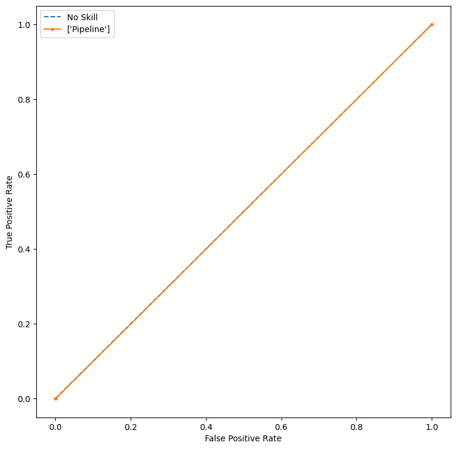

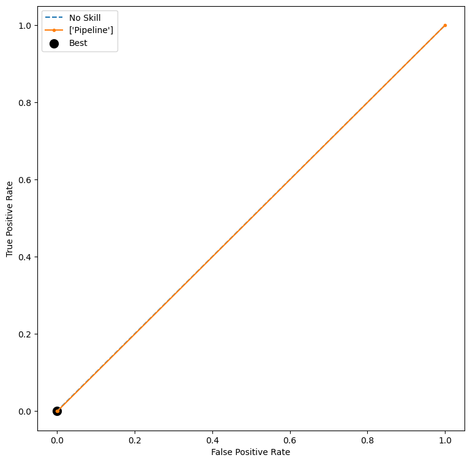

```
ROC-AUC score of the model: 0.49943194565772575
Accuracy of the model: 0.9989128102424719

Classification report:
              precision    recall  f1-score   support

           0       1.00      1.00      1.00    209487
           1       0.00      0.00      0.00       228

    accuracy                           1.00    209715
   macro avg       0.50      0.50      0.50    209715
weighted avg       1.00      1.00      1.00    209715


Confusion matrix:
[[209487      0]
 [   228      0]]
```

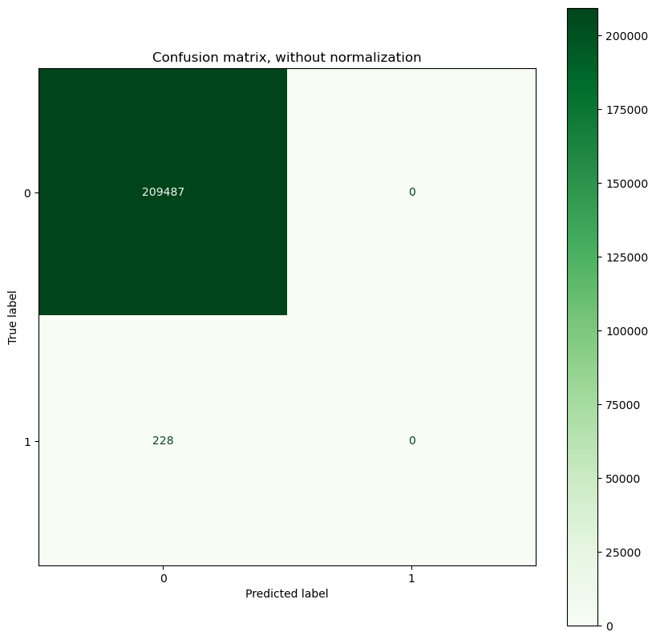

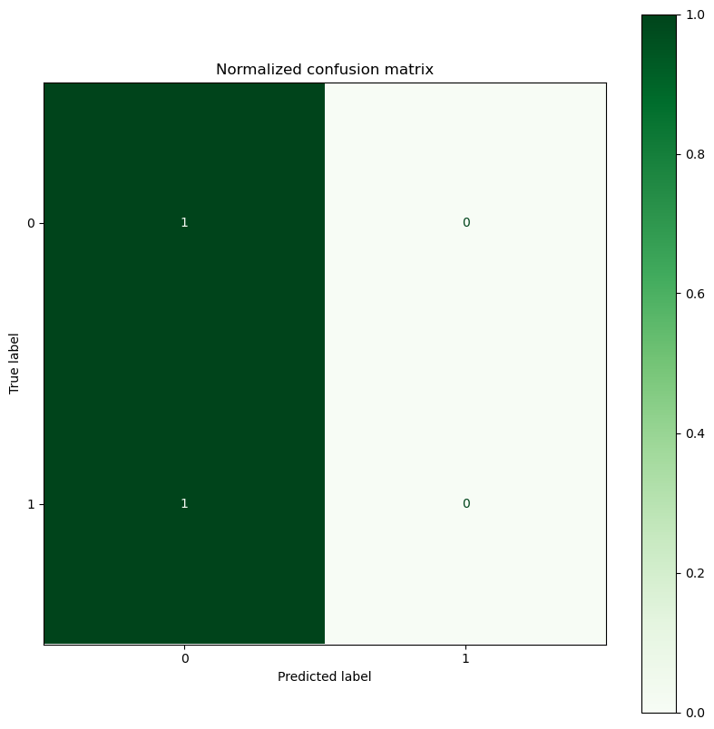

```python
model_analysis(dummy, xtest, ytest)
```

## Naive-Bayes

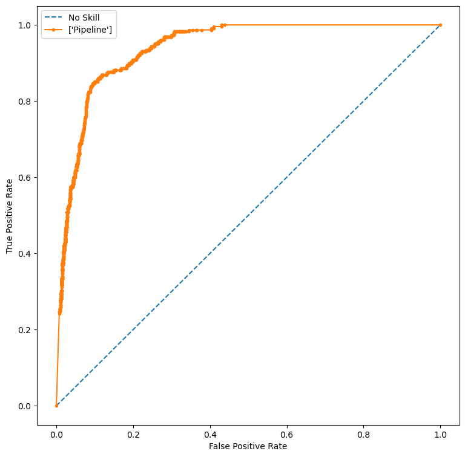

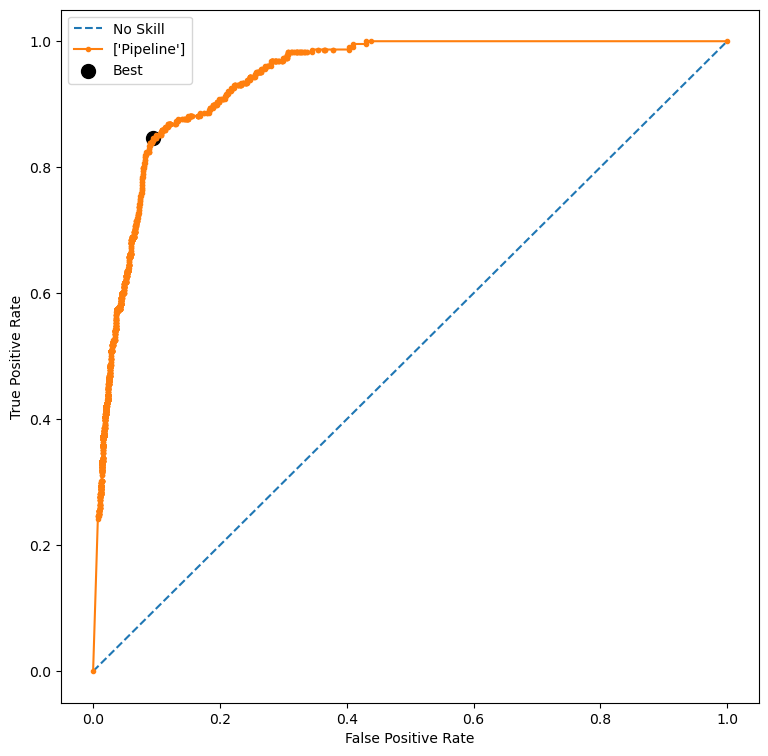

```
ROC-AUC score of the model: 0.9388807172977865
Accuracy of the model: 0.9056767517821805

Classification report:
              precision    recall  f1-score   support

           0       1.00      0.91      0.95    209487
           1       0.01      0.84      0.02       228

    accuracy                           0.91    209715
   macro avg       0.50      0.87      0.48    209715
weighted avg       1.00      0.91      0.95    209715


Confusion matrix:
[[189742  19745]
 [    36    192]]
```

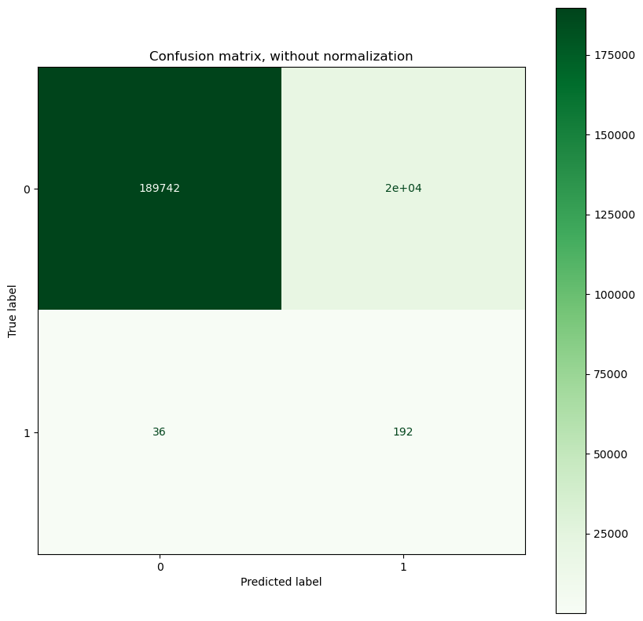

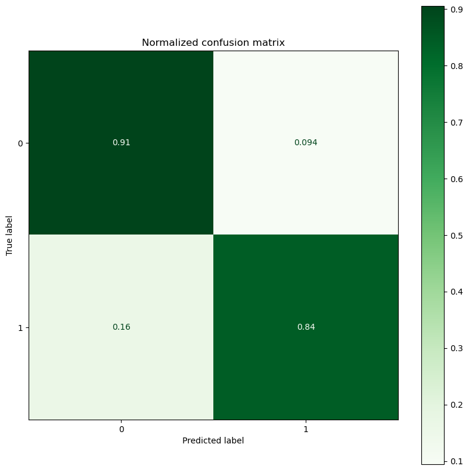

```python
model_analysis(naive_bayes, xtest, ytest)
```

## Regresión Logística (Ridge)

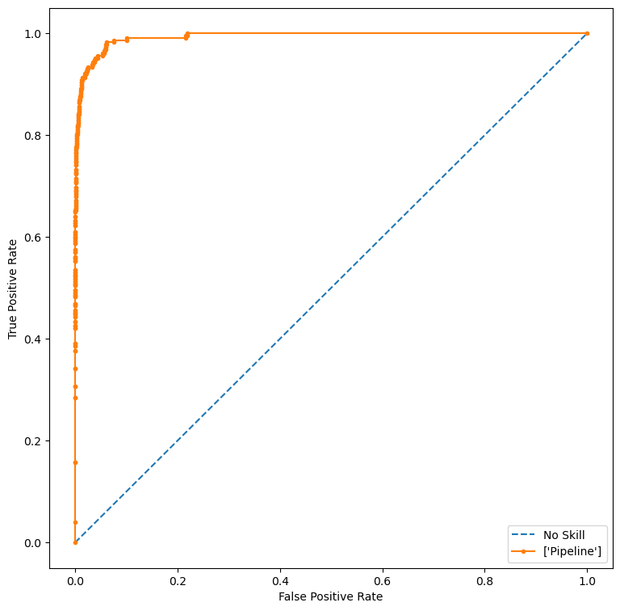

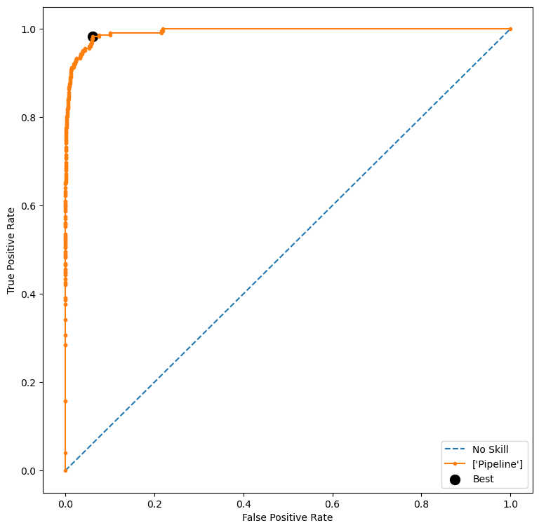

```
ROC-AUC score of the model: 0.9932801382223694
Accuracy of the model: 0.9379491214266982

Classification report:
              precision    recall  f1-score   support

           0       1.00      0.94      0.97    209487
           1       0.02      0.98      0.03       228

    accuracy                           0.94    209715
   macro avg       0.51      0.96      0.50    209715
weighted avg       1.00      0.94      0.97    209715


Confusion matrix:
[[196479  13008]
 [     5    223]]
```

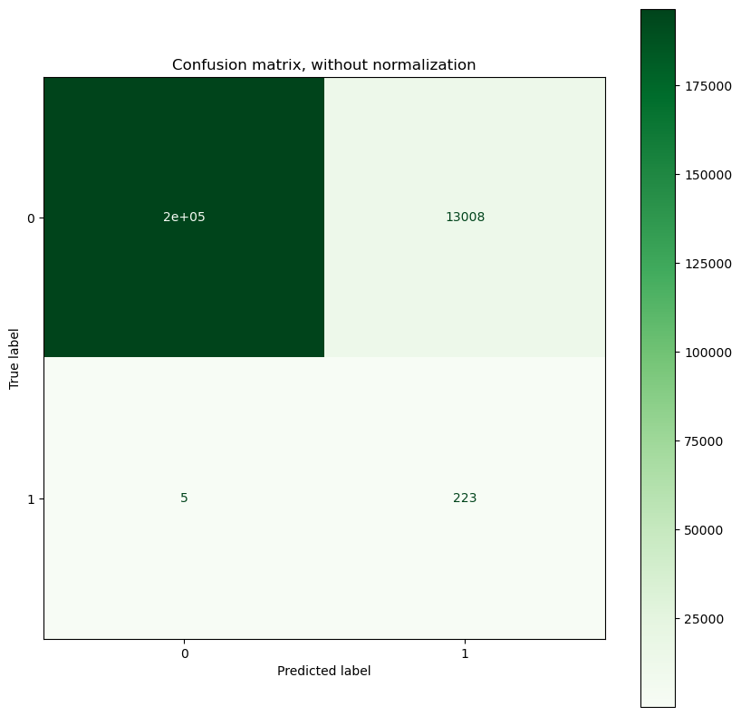

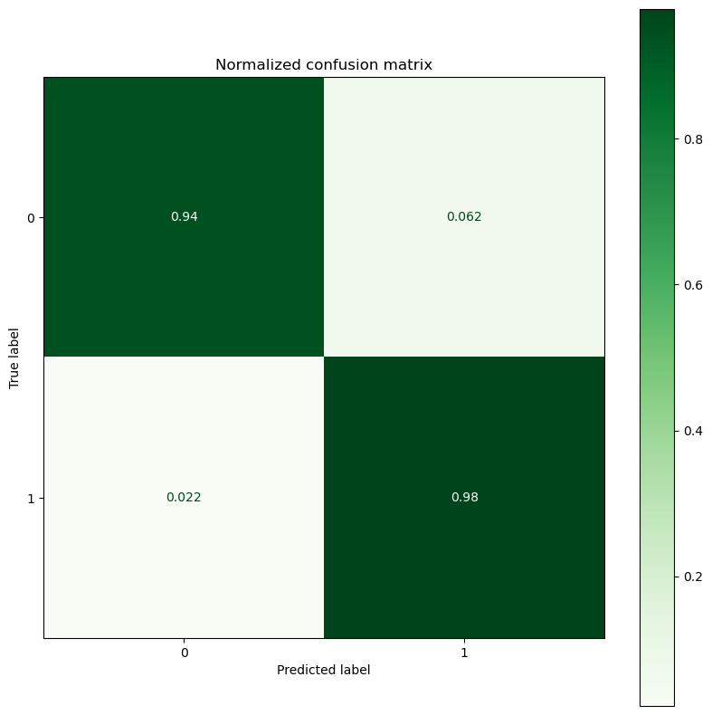

```python
model_analysis(logistic_ridge, xtest, ytest)
```

## Regresión Logística (Lasso)

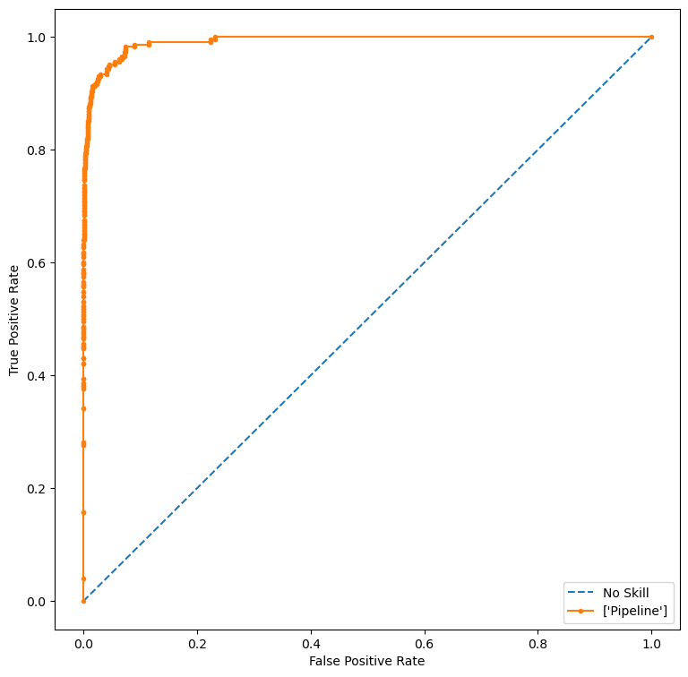

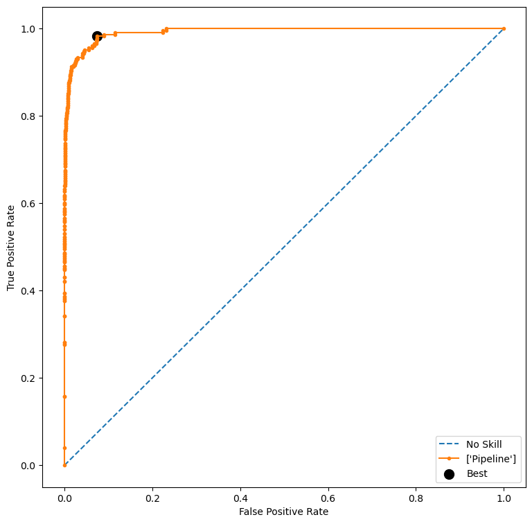

```
ROC-AUC score of the model: 0.9923340090860221
Accuracy of the model: 0.9261330853777746

Classification report:
              precision    recall  f1-score   support

           0       1.00      0.93      0.96    209487
           1       0.01      0.98      0.03       228

    accuracy                           0.93    209715
   macro avg       0.51      0.95      0.49    209715
weighted avg       1.00      0.93      0.96    209715


Confusion matrix:
[[194001  15486]
 [     5    223]]
```

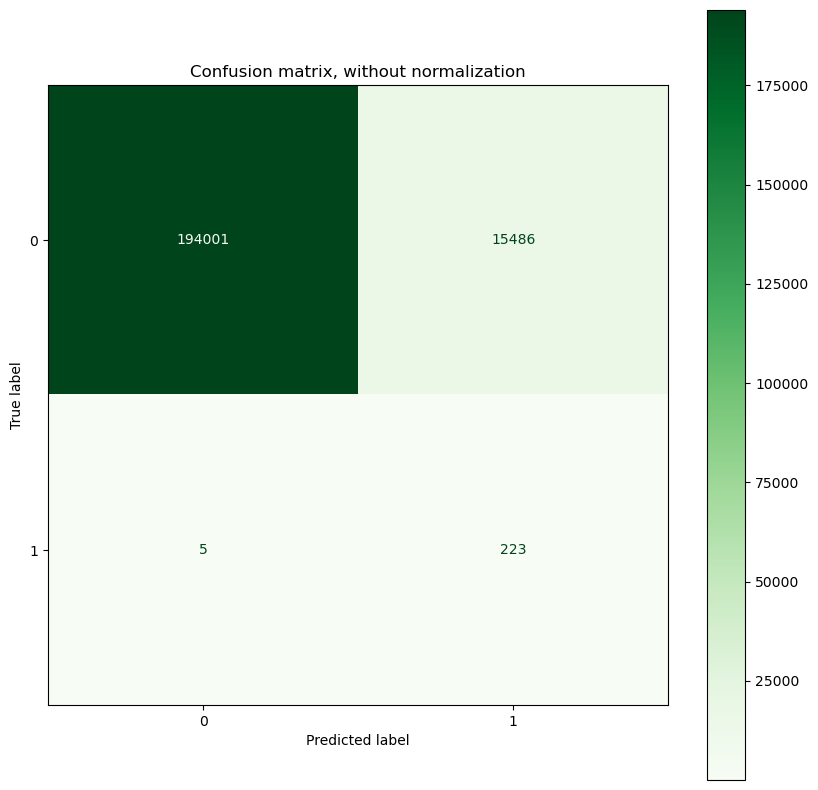

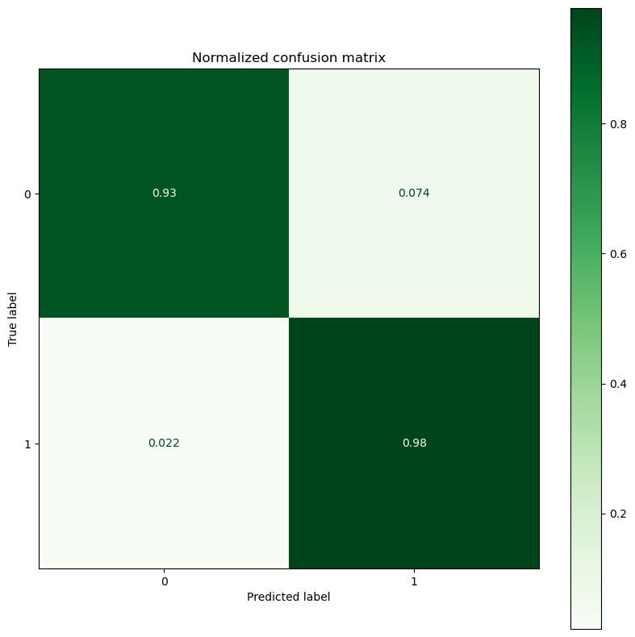

```python
model_analysis(logistic_lasso, xtest, ytest)
```

# Support Vector Machine (Linear)

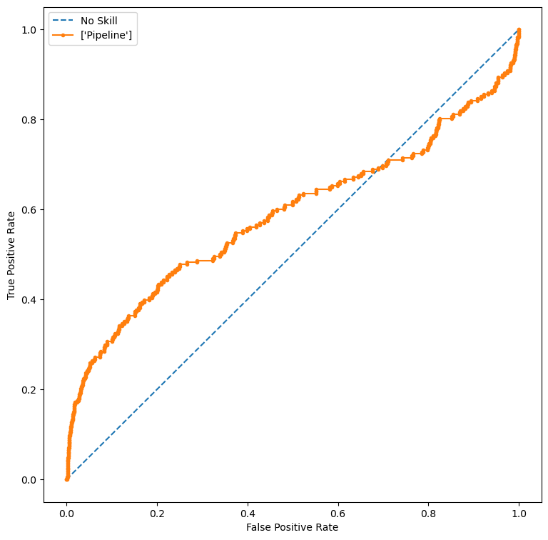

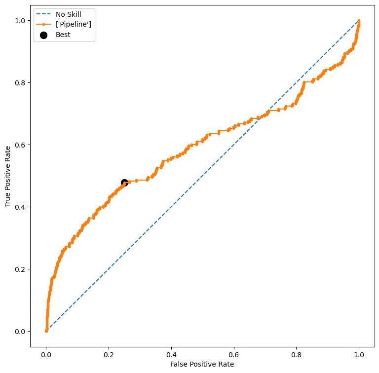

```
ROC-AUC score of the model: 0.5882601139508804
Accuracy of the model: 0.7483680232696756

Classification report:
              precision    recall  f1-score   support

           0       1.00      0.75      0.86    209487
           1       0.00      0.47      0.00       228

    accuracy                           0.75    209715
   macro avg       0.50      0.61      0.43    209715
weighted avg       1.00      0.75      0.86    209715


Confusion matrix:
[[156836  52651]
 [   120    108]]
```

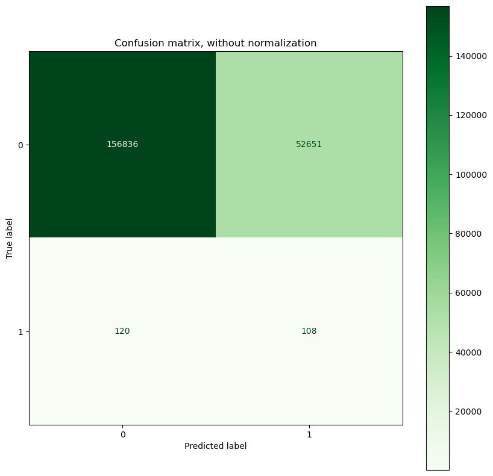

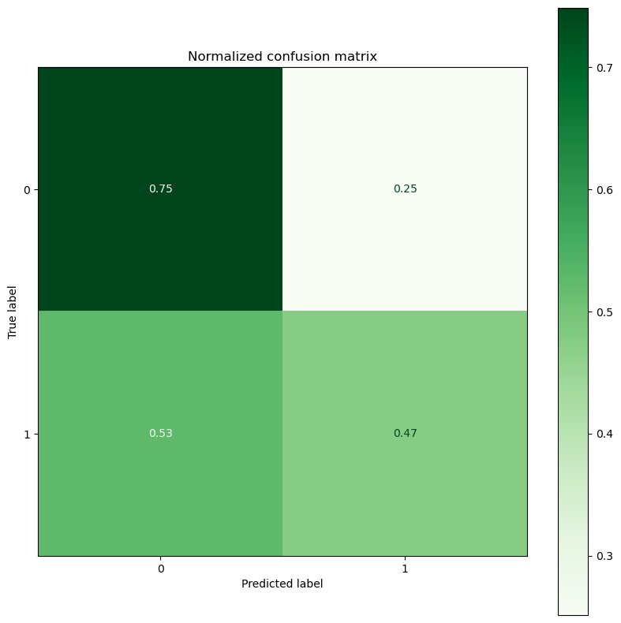

```python
model_analysis(support_vector, xtest, ytest)
```

Este modelo nos da peores resultados ya que tiene un accuracy del 74% ( de todos los modelos analizados es el valor más bajo), y además no mejora la matriz de corrlación con un 25% de falsos positivos. Además, tarda en ejecutarse al menos 2 horas.

## Random Forest

[figure not shown]

[figure not shown]

[output not shown]

[figure not shown]

[figure not shown]

[output not shown]

```python
model_analysis(random_forest, xtest, ytest)
```

# Desicion Tree

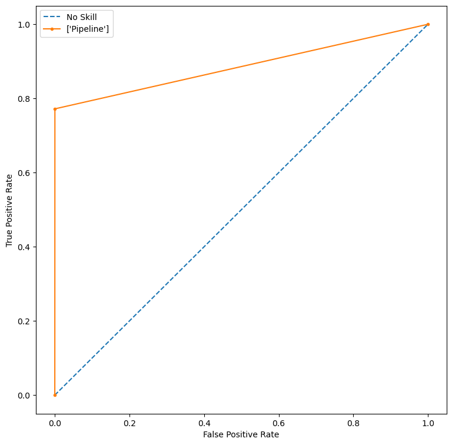

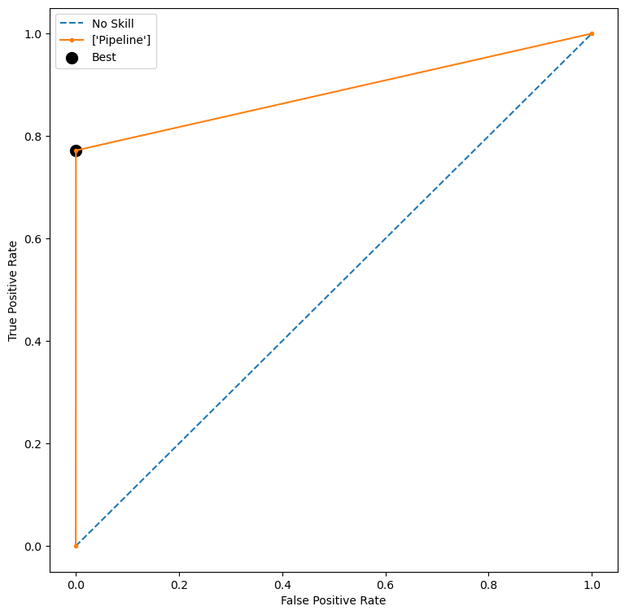

```
ROC-AUC score of the model: 0.8858240920866086
Accuracy of the model: 0.9989128102424719

Classification report:
              precision    recall  f1-score   support

           0       1.00      1.00      1.00    209487
           1       0.00      0.00      0.00       228

    accuracy                           1.00    209715
   macro avg       0.50      0.50      0.50    209715
weighted avg       1.00      1.00      1.00    209715


Confusion matrix:
[[209487      0]
 [   228      0]]
```

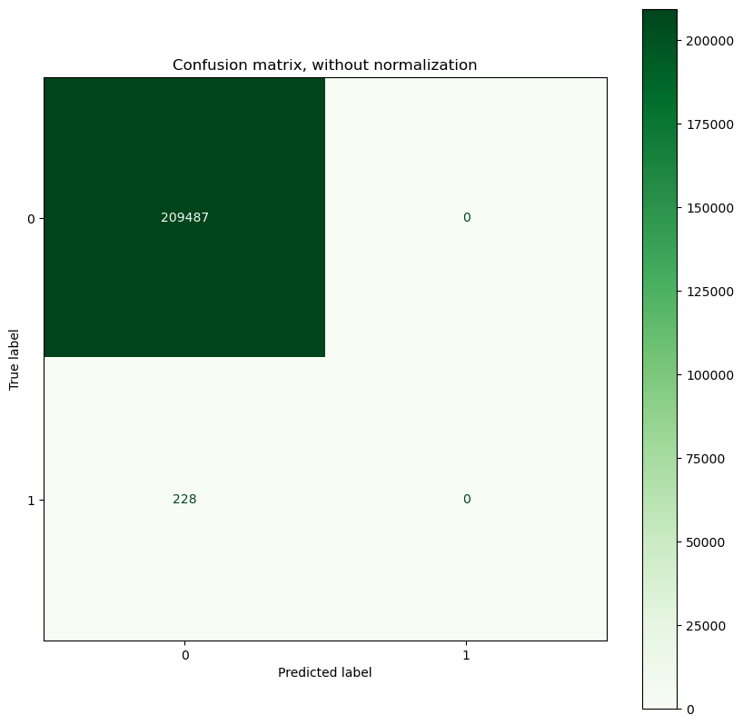

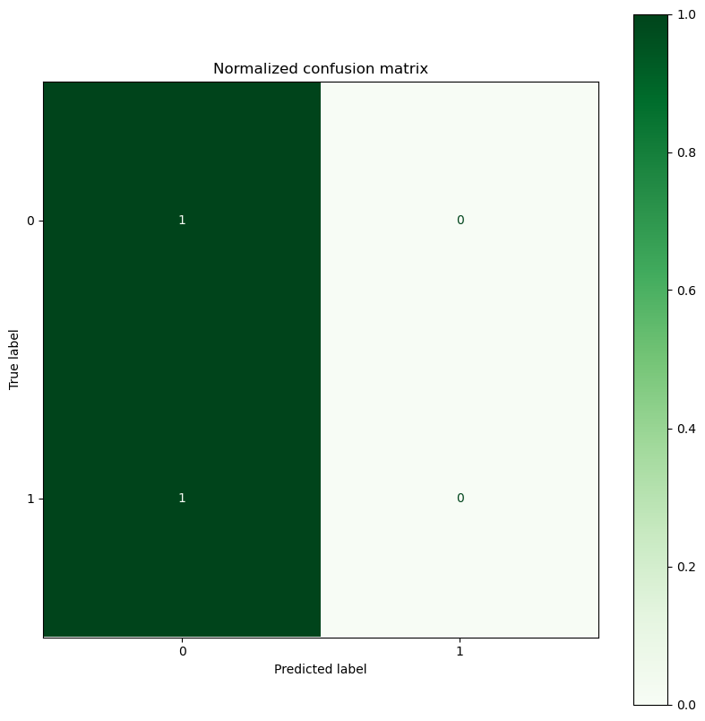

```python
model_analysis(decicion_tree, xtest, ytest)
```

El modelo de Arbol de Decisón es como el modelo Dummy, no detecta ningún fraude. Es de esperar obtener estos resultados, ya que es sólo un árbol, mientras que por ejemplo en el Random Forest son más.

## XGBoost

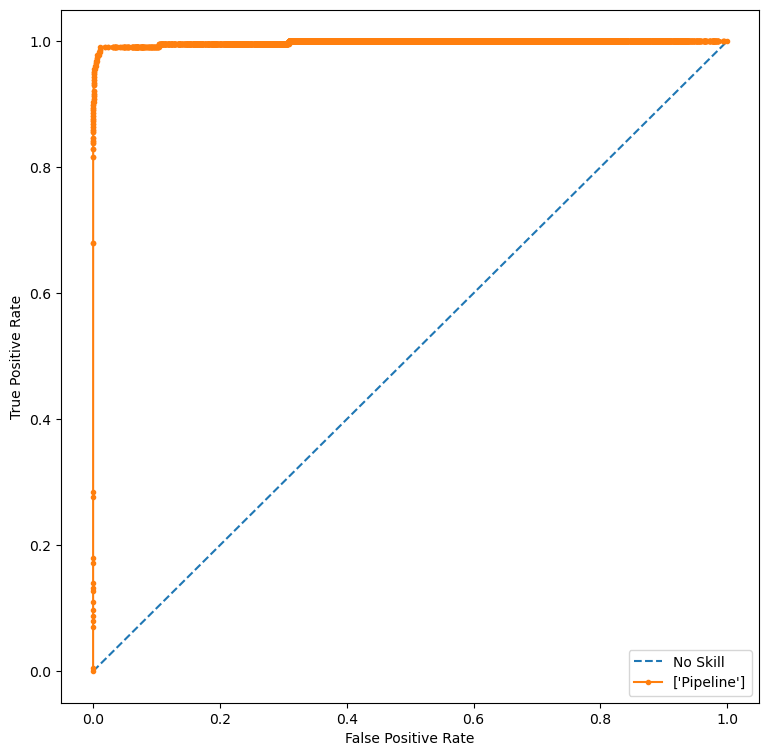

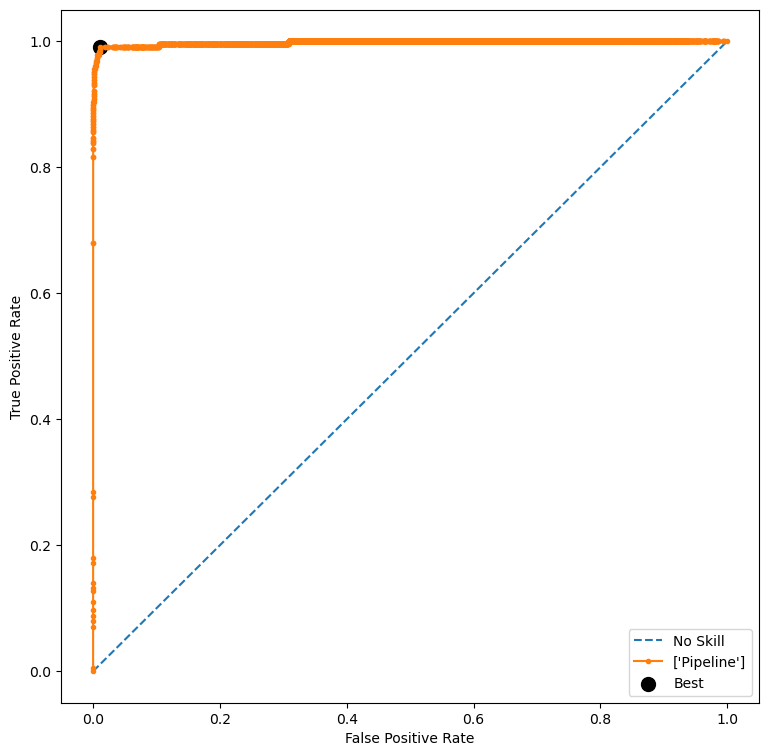

```
ROC-AUC score of the model: 0.997891612250109
Accuracy of the model: 0.9888133896001716

Classification report:
              precision    recall  f1-score   support

           0       1.00      0.99      0.99    209487
           1       0.09      0.99      0.16       228

    accuracy                           0.99    209715
   macro avg       0.54      0.99      0.58    209715
weighted avg       1.00      0.99      0.99    209715


Confusion matrix:
[[207144   2343]
 [     3    225]]
```

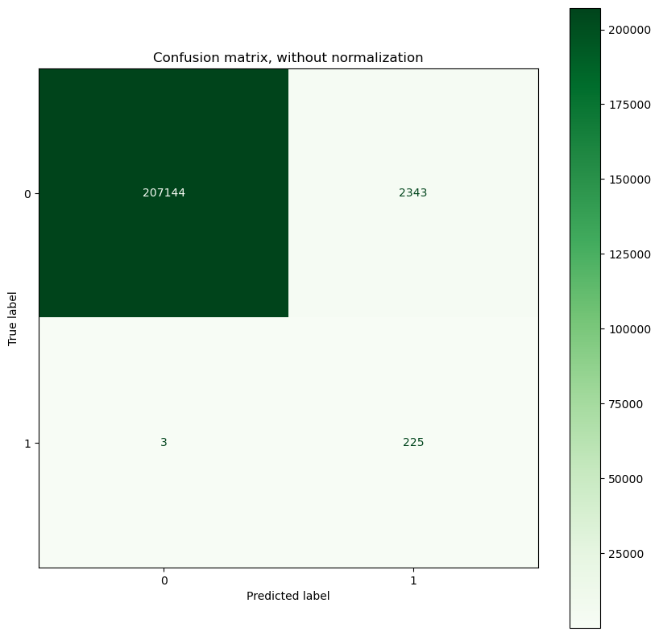

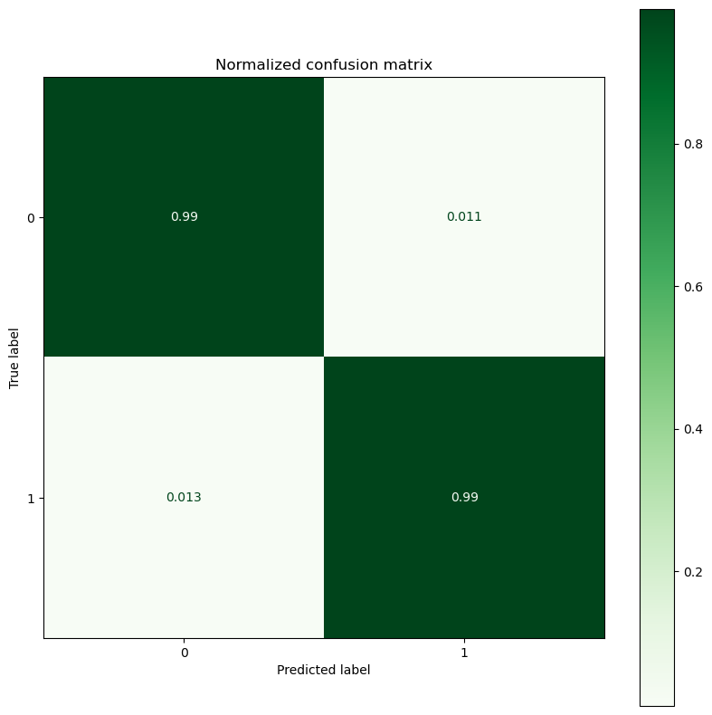

```python
model_analysis(xgboost, xtest, ytest)
```

XGboost model que predice mejor y los valores de accuracy y ROC-AUC también salen bien. Se puede considerar para optimizarlo.Porcentages de falsos positivos y negativos han bajado y detection de los verdaderos fraudes ha subido hasta 99%.